# Section 7 Compliance Exploration

Preliminary analyses

Jacob Malcom, Defenders of Wildlife, and Tiffany Kim, University of Maryland

# Background

Section 7 of the U.S. Endangered Species Act (ESA) directs federal agencies to use their authority to further the conservation of ESA-listed species. One way they do that is by “consulting” with the U.S. Fish and Wildlife Service or the National Marine Fisheries Service if an action they permit, fund, or carry out may affect listed species. While section 7 may be the strongest part of the ESA, it is difficult to determine if the section is living up to its full potential because there is no information about whether agencies are complying with the terms of the consultations.

http://www.nmfs.noaa.gov/pr/pdfs/laws/esa_section7.pdf

One possibly efficient solution to the challenge of monitoring compliance is using remotely sensed data, e.g., satellite and aerial imagery. Building off of our section 7 database, we randomly selected hundreds of consultations to investigate more deeply. We have two primary goals with this work:

[Malcom and Li 2015 (PNAS)](http://www.pnas.org/content/112/52/15844.abstract)

1. Estimate the rate at which we can identify the (likely) action site given information in the section 7 database; and
2. If the action site is found, estimate the area of habitat loss, which will allow us to estimate the total acreage of habitat lost under section 7.

This is a preliminary analysis of the data that TK has collected. The code that generated this document (“prelim_report_v0-1.Rmd”) contains all of the code needed to run the analyses presented herein.

# Preliminary Analyses

## **Observability**

First we compare the distribution of whether we expected to see something to the rate at which we actually saw something. First, the formal consultations:

**Expected (left) and observed (right) observabilitites given the work types of selected *formal* consultations.**

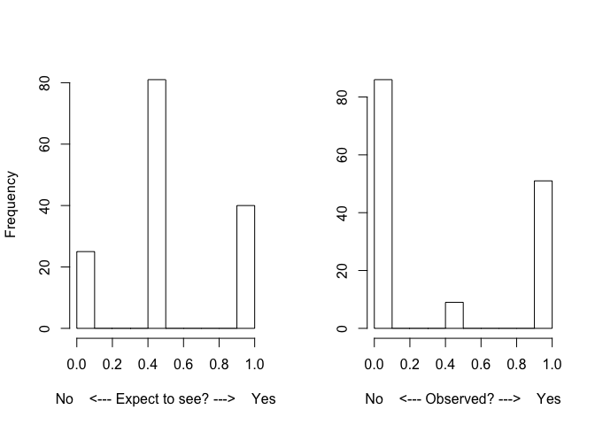

And now the informal consultations:

**Expected (left) and observed (right) observabilitites given the work types of selected *informal* consultations.**

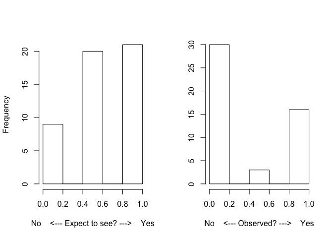

For the 50 informal consultations evaluated so far, we expected more in the “will see” category (1; ~22). But we end up losing a few, and see more unobservable.

## Observability by Work Category

Next, we would like to know how variable detectability is within work categories. It may be that some work categories are particularly amenable to remote sensing but others are not.

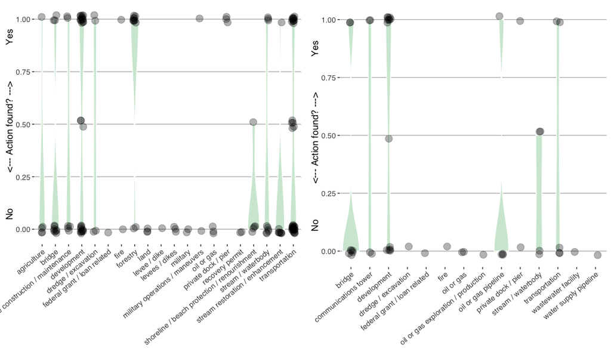

**Violin-and-point plot of observability of *formal* (left) and *informal* (right) consultations by work category.** Points near the 1 line are were observed; 0.5 were possible detections; and 0 were not detectable. Wider sections of violin plots indicate more data points, which may be partially obscured by overlapping points.

We’re able to see actions addressed in *informal* consultations consistently for a few work categories (dots at 1 on y-axis), but many consultations are not visible from imagery (at 0), or we’re not sure (at 0.5). Note that the work categories are different than formal consultation categories.

## Sidetrack: Distribution of image years

What is the distribution of earliest images available across the sites evaluated?

```
##                  Min.               1st Qu.                Median
## "1939-12-01 00:00:00" "1993-04-08 12:00:00" "1993-07-16 12:00:00"
##                  Mean               3rd Qu.                  Max.
## "1991-08-07 06:34:31" "1994-09-01 00:00:00" "2005-03-01 00:00:00"
```

**The distribution of the earliest images available through Google Earth Pro (R) at sites evaluated during section 7 consultation.**

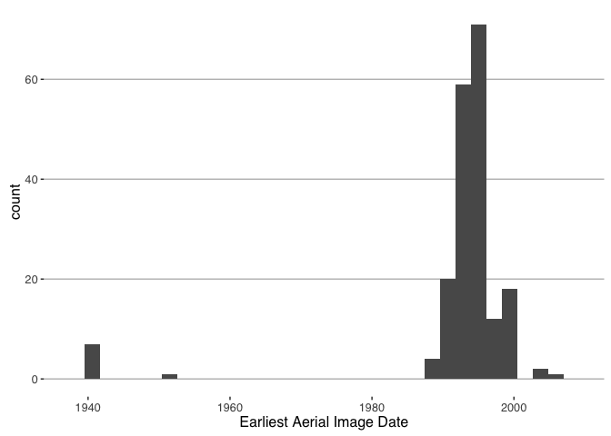

If so desired, we can go back to ca. 1940 in some areas to measure how much habitat has changed over 65 years. But, given this initial data, most of the time we’ll only be able to go back to ca. 1992.

## On-track: What are observability rates?

*Formal consultation observabilities (overall)*

```
## Observability:
##   0.391797110174594
## Number of consultations in set:
##   1661
## Number of consultations we expect to see effects:
##   650.775
```

*Informal consultation observabilities (overall)*

```
## Observability:
##   0.351479012345679
## Number of consultations in set:
##   20250
## Number of consultations we expect to see effects:
##   7117.45
```

35-39% observability isn’t great…I think we need to see how the number of consultations per work type compares to the observability.

Work “type” is a finer categorization than work “category”.

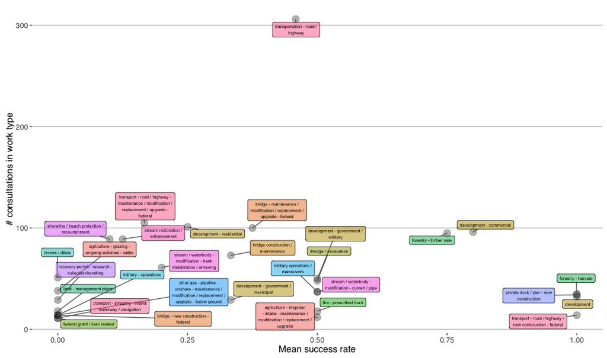

**Observability vs. number of *formal* consultations by work type.** Each point is the mean observability of that work type. Work categories are represented by the color of the labels.

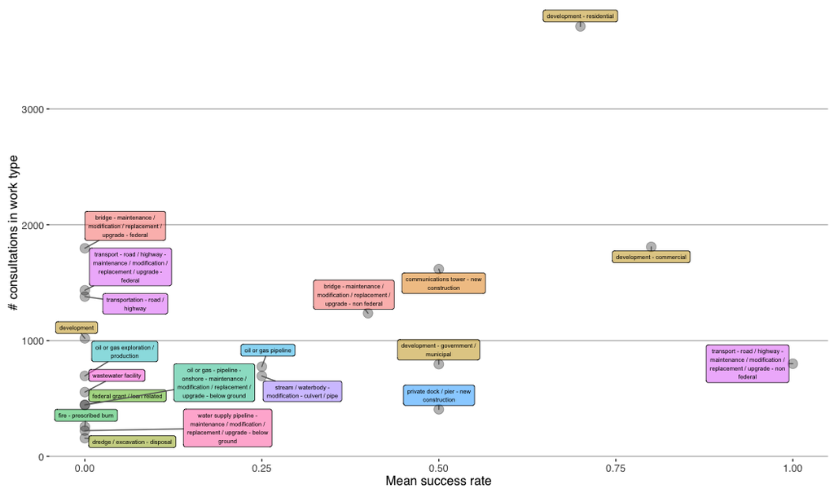

**Observability vs. number of *informal* consultations by work type.** Each point is the mean observability of that work type. Work categories are represented by the color of the labels.

*It’s unfortunate that the labels overlap as much as they do, but without making a dynamic figure, this is the best I think we can hope for.*

## **Goal 2: Habitat area lost**

First, we should check the distributions of area measurements.

**Distribution of observed area (acres) of habitat destroyed or significantly modified.** More data is needed to fill out this distribution a bit.

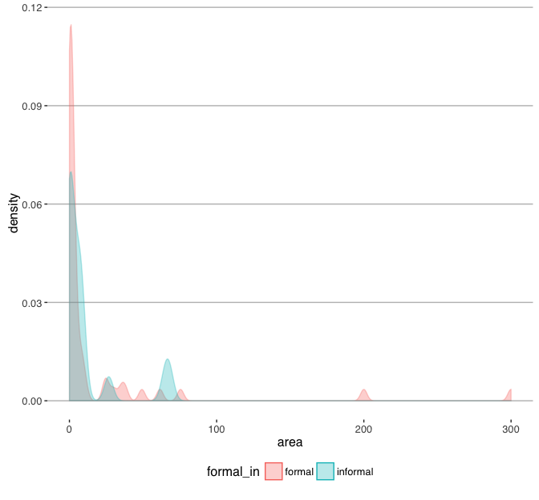

Per Goal 2, we would like to say something about the total area of habitat that has been “given away” under section 7. Even though the sample sizes are relatively small at this point, we can bootstrap sample from the areas that TK has measured and get a distribution of estimated areas affected. First the formal consultations:

Bootstrapping is simply taking a random sample from among a starting dataset to calculate a particular statistic (in this case, the sum of areas) many times. From these samples we can get an estimated distribution of the statistic.

**Distribution of total estimated area ‘lost’ from section 7 *formal* consultations.** For each bootstrap replicate, *n* = 6,832 random samples were taken from the observed distribution of areas, then summed.

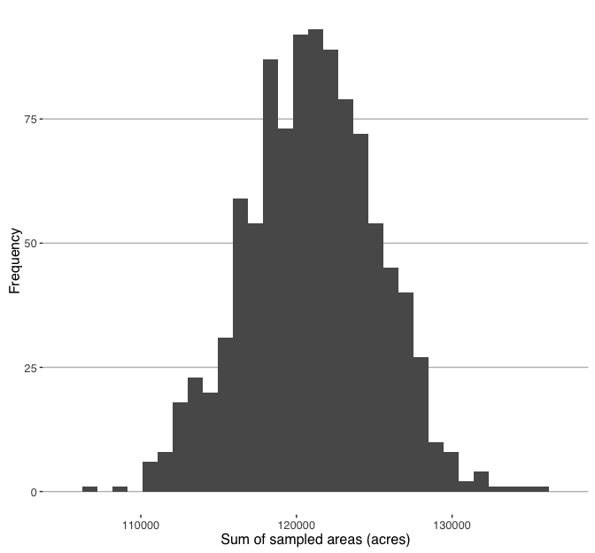

```
## Mean: 120994.00051
## 95% CI: 112687.03075 - 128614.18625
```

So about 120,000 acres for formal consultations…

**Distribution of total estimated area ‘lost’ from section 7 *informal* consultations.** For each bootstrap replicate, *n* = 81,461 random samples were taken from the observed distribution of areas, then summed.

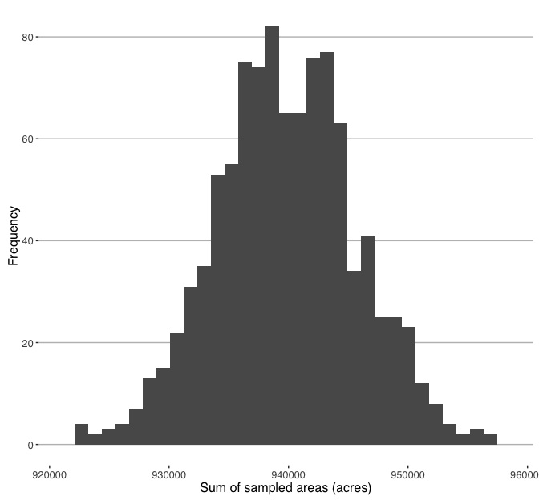

```
## Mean: 939771.14051
## 95% CI: 928297.7305 - 951091.073
```

…and about 940,000 acres for informal consultations (!).

# Discussion

This is only a preliminary analysis, but the results suggest a few interesting items.

1. There are likely a large number of actions evaluated under section 7 for which aerial imagery isn’t going to work very well. A few work categories in particular might be warranted, but we aren’t going to be able to monitor compliance of even a majority of actions.
2. The preliminary estimates of the total area of habitat lost under section 7 suggests that the situation isn’t good. Over 1,000,000 acres since 2008!
3. But this really begs the question, *How much habitat was lost from 2008-2015 across the entire US?* (Detractors of the ESA claims that it “kills the economy”. If it turns out that consultations account for a small percentage of the total habitat lost (a measure of economic output) then their claims are clearly bogus.)

There will be much more, later.

*Any views expressed in this working paper are not necessarily the views of Defenders of Wildlife. This document is nothing more than a working paper, tracking work in progress.*

This work by [Defenders of Wildlife](http://defenders.org) is licensed under a [Creative Commons Attribution 4.0 International License](http://creativecommons.org/licenses/by/4.0/).